# Fitting models to count data

Mark Scheuerell

22 May 2026

# Background

These lab exercises focus on fitting and evaluating models for count data. These include regular Poisson and negative binomial regression models, and zero-truncated, zero-altered, and zero-inflated models. We’ll use the examples we saw in lecture to demonstrate the various options in **R** for fitting models, evaluating their goodness-of-fit, and examining model diagnostics.

Earlier in the course we modeled counts as (possibly log transformed) density, where

$$\text{Density}_i = f (\text{Count}_i, \text{Area}_i) \\
\Downarrow \\
\text{Density}_i = \frac{\text{Count}_i}{\text{Area}_i} \\$$

With GLMs for count data, we instead shift our focus to

$$\text{Count}_i = f (\text{Area}_i, \dots)$$

## Components of a GLM

As we’ve seen for other GLMs, there are 3 important components to a regression model for count data:

1. Distribution of the data: $y \sim f_{\theta}(y)$
2. Link function: $g(\eta)$
3. Linear predictor: $\eta = \mathbf{X} \boldsymbol{\beta}$

$$\log (\mu) = \mathbf{X} \boldsymbol{\beta}$$

and its inverse mean function given by

$$\mu = \exp (\mathbf{X} \boldsymbol{\beta})$$

# Regular counts

Let’s consider a regular Poisson regression model for catches of spot prawns $y_i$ as a function of bait type $C_i$ and water temperature $T_i$, such that

$$\begin{aligned}
\text{data distribution:} & ~~ y_i \sim \text{Poisson}(\lambda_i) \\
\\
\text{link function:} & ~~ \text{log}(\lambda_i) = \mu_i \\ \\
\text{linear predictor:} & ~~ \mu_i = \alpha + \beta_1 C_i + \beta_2
T_i
\end{aligned}$$

## Catches of spot prawns

The first step is to simulate the catch data. We’ll assume that catches of spot prawns increase with water temperature, and that catches are generally greater when using fish as bait compared to chicken.

```r
set.seed(514)
## sample size
nn <- 113
## average catch
b0 = 3.5
## effect of chicken as bait
b_bait <- 0.1
## effect of temperature
b_temp <- 0.03
## bait type
fish <- sample(c(0, 1), nn, replace = TRUE)
## water temp
temp <- runif(nn, 7, 13)
## linear predictor
eta <- exp(b0 + b_bait * fish + b_temp * temp)
## catches
catch <- rep(NA, length(eta))
for(i in 1:nn) {
  catch[i] <- rpois(1, eta[i])
}
## combine data
prawns <- data.frame(cbind(catch, fish, temp))
```

Here are plots of catch versus water temperature and bait type.

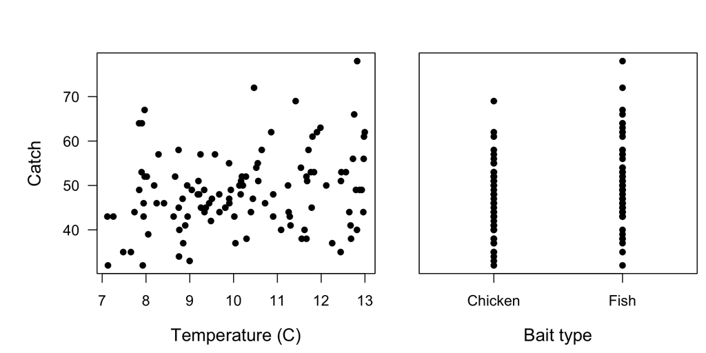

```r
## set plot area
par(mfrow = c(1, 2),
    mai = c(0.9, 0.4, 0.6, 0.1),
    omi = c(0, 0.7, 0, 0), bg = NA,
    cex.main = 1.2, cex.lab = 1.2)
## plot temp vs catch
plot(temp, catch, las = 1, pch = 16, xpd = NA,
     xlab = "Temperature (C)", ylab = "Catch")
## plot bait vs catch
plot(fish + 1, catch, las = 1, pch = 16,
     xlim = c(0.5, 2.5), xlab = "Bait type", xaxt = "n",
     yaxt = "n", ylab = "")
axis(1, at = c(1, 2), labels = c("Chicken", "Fish"))
```

## Model fitting

Fitting Poisson regression models proceeds as with other GLMs using `glm()`. Recall that we must specify both the `family` of the distribution and the `link` type. By default `glm()` assumes the canonical link once a family is specified, but it’s good “defensive programming” to explicitly include it anyway. Here is our model for catch as a function of temperature and bait type.

```r
## Poisson regression
cmod <- glm(catch ~ temp + fish, data = prawns,
            family = poisson(link = "log"))
faraway::sumary(cmod)
```

```
##              Estimate Std. Error z value  Pr(>|z|)
## (Intercept) 3.5717603  0.0856999 41.6775 < 2.2e-16
## temp        0.0258438  0.0080182  3.2231  0.001268
## fish        0.0803358  0.0275039  2.9209  0.003490
##
## n = 113 p = 3
## Deviance = 152.84428 Null Deviance = 171.01822 (Difference = 18.17393)
```

All three model coefficients are “significant” at the $\alpha$ = 0.05 level. Recall that the true values are `(Intercept)` = 3.5, `temp` = 0.03, and `fish` = 0.1, so our estimates are reasonably close to the true values. Also recall that because bait type is a categorical predictor with 2 levels, the effect of `fish` represents the case where the bait type is fish. If the bait type is chicken, then the effect is zero.

We also get an estimate of the model deviance (`Deviance`), which is ~152.84. To extract the deviance from a fitted model, you can use `deviance(cmod)` or `summary(cmod)$deviance`.

## Inference

Once we’ve fit out model, it’s natural to wonder about parameter (un)certainty, goodness of fit, and whether model diagnostics reveal any possible problems with our model.

### Confidence intervals for $\beta_i$

We can easily estimate the CI’s on the model parameters with `confint()`. Here are the upper and lower 95% CI’s on our model parameters with the MLEs.

```r
## CI's for prawn model
ci_prawns <- confint(cmod)
ci_tbl <- cbind(ci_prawns[,1], coef(cmod), ci_prawns[,2])
colnames(ci_tbl) <- c("Lower", "MLE", "Upper")
signif(ci_tbl, 3)
```

```
##              Lower    MLE  Upper
## (Intercept) 3.4000 3.5700 3.7400
## temp        0.0101 0.0258 0.0416
## fish        0.0265 0.0803 0.1340
```

We saw in lecture that we can have possible biases in $\text{SE}(\beta)$, which means we may want to compute CI’s based on the *profile likelihood*. To calculate the profile likelihoods, we simply evaluate the likelihood at each point along a sequence of possible parameter values. Here are the profile likelihoods for the effects of temperature and bait type.

```r
## number of points to profile
nb <- 200

## possible beta's
beta_bait <- seq(0, 0.2, length = nb)
beta_temp <- seq(-0.01, 0.07, length = nb)

## calculate neg-LL of possible beta_temp
## fix beta_bait at its MLE
plt <- rep(NA, nb)
for(i in 1:nb) {
  mm <- glm(catch ~ 1 + offset(beta_temp[i] * temp + offset(coef(cmod)[3] * fish)),
            data = prawns,
            family = poisson(link = "log"))
  plt[i] <- -logLik(mm)
}

## calculate neg-LL of possible beta_bait
## fix beta_temp at its MLE
plb <- rep(NA, nb)
for(i in 1:nb) {
  mm <- glm(catch ~ 1 + offset(coef(cmod)[2] * temp + offset(beta_bait[i] * fish)),
            data = prawns,
            family = poisson(link = "log"))
  plb[i] <- -logLik(mm)
}
```

Here are plots of the profile likelihoods and the threshold value based upon the 95$^{th}$ percentile for a $\chi^2_{1}$ on one degree of freedom (i.e., the difference in the number of parameters between the model and a model without the parameter). The blue points are the estimated lower and upper 95% CI.

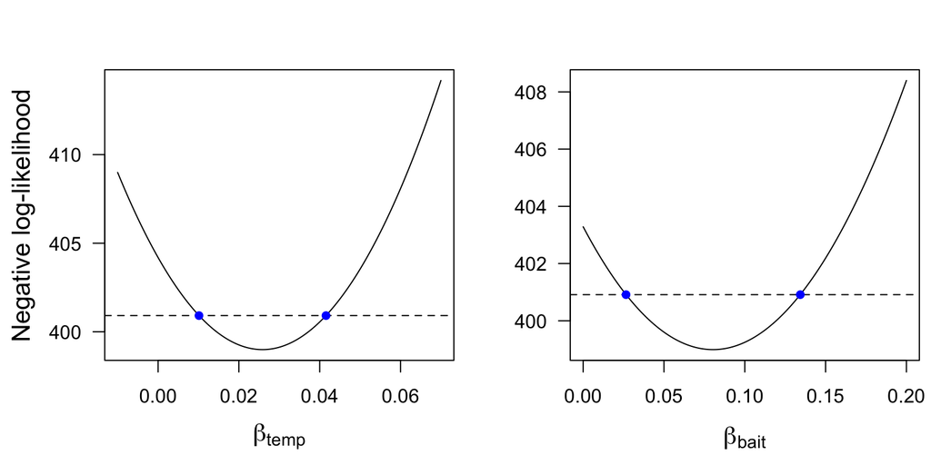

```r
## set plot area
par(mfrow = c(1, 2),
    mai = c(0.9, 0.9, 0.6, 0.1),
    omi = c(0, 0, 0, 0),
    cex.lab = 1.3)

## threshold value for CI
crit <- -(logLik(cmod) - qchisq(0.95, 1) / 2)

## likelihood profile for temp
plot(beta_temp, plt, type = "l", las = 1,
     ylab = "Negative log-likelihood", xlab = expression(beta[temp]))
abline(h = crit, lty = "dashed")
points(confint(cmod)[2,], c(crit, crit), pch = 16, col = "blue")

## likelihood profile for bait
plot(beta_bait, plb, type = "l", las = 1,
     ylab = "", xlab = expression(beta[bait]))
abline(h = crit, lty = "dashed")
points(confint(cmod)[3,], c(crit, crit), pch = 16, col = "blue")
```

### Goodness of fit

It’s natural to ask how well a model fits the data. As with logistic regression models based upon a binomial distribution, we can check the deviance $D$ against a $\chi^2$ distribution. Recall that the deviance for any model is

$$D_i = \text{-}2 \left[ \log \mathcal{L}(M_i) - \log \mathcal{L}(M_0)
\right]$$

where $M_i$ is the model of interest and $M_0$ is an intercept-only model. The log-likelihood for a Poisson is given by

$$\log \mathcal{L}(y; \lambda) = \sum_{i=1}^{n} \left[ y_{i} \log
(\lambda)- \lambda - \log \left( y_{i}! \right) \right]$$

and hence the deviance for a Poisson is

$$\log \mathcal{L}(y; \lambda) = \sum_{i=1}^{n} \left[ y_{i} \log (y_i /
\hat{\lambda}) - (y_i - \hat{\lambda}) \right]$$

The null hypothesis for our $chi^2$ test is that our model is correctly specified and it adequately fits the data. Here is the code for our test.

```r
## deviance of prawn model
D_full <- summary(cmod)$deviance
## LRT with df = n - k
(p_value <- pchisq(D_full, nn - length(coef(cmod)),
                   lower.tail = FALSE))
```

```
## [1] 0.004338247
```

This $p$-value is rather small so we reject the $H_0$, and conclude that the model does not provide an adequate fit to the data. But wait–we simulated the data according to a Poisson distribution, so why did this test conclude a lack of fit? In this case the reason is because the use of a $\chi^2$ distribution for the likelihood ratio test relies on asymptotic properties of the distribution, in that a Poisson distribution approximates a normal distribution as the mean gets larger. Therefore, there are no guarantees, even when the sample size is large, that the test will be valid.

Recall from lecture that the assumption of $D \sim \chi^2_{n - k}$ can be violated with Poisson models unless $\lambda$ is large. Another option is to use the same Pearson’s $X^2$ statistic we saw for binomial models, where

$$X^2 = \sum_{i = 1}^n \frac{(O_i - E_i)^2}{E_i} \sim \chi^2_{(n - k)} \\$$

So for our Poisson model

$$X^2 = \sum_{i=1}^{n} \frac{(y_i - \hat{\lambda}_i)^2}{\hat{\lambda}_i}
\sim \chi^2_{n - k}$$

Again our null hypothesis is that our model is correctly specified. Here is the code to conduct the test.

```r
## numerator
nm <- (prawns$catch - fitted(cmod))^2
## denominator
dm <- fitted(cmod)
## Pearson's
X2 <- sum(nm / dm)
## test
(p_value <- pchisq(X2, nn - length(coef(cmod)), lower.tail = FALSE))
```

```
## [1] 0.002860662
```

We again the $p$-value is rather small so we reject the $H_0$, and conclude that the model does not provide an adequate fit to the data (with the same caveat as above).

### Fitted values & CI’s

We can obtain the fitted values and confidence intervals around the fits in a manner analogous to that for logistic regression models. The important thing here is to remember that we want to estimate the uncertainty in log-space and then back-transform the intervals into count space. For ease in interpretation, we also want to calculate the CI’s for the fits with both bait types as a function of temperature.

```r
## sorted temp
tmp <- prawns[order(prawns[,3]),]
## split data into bait types
fdat <- tmp[tmp$fish == 1,]
cdat <- tmp[tmp$fish == 0,]

## fitted values
fish <- predict(cmod, fdat, se.fit = TRUE, type = "link")
chkn <- predict(cmod, cdat, se.fit = TRUE, type = "link")

## t value
t_crit <- qt(0.975, nn - length(coef(cmod)))

## CI's for fish
fish_fit <- exp(fish$fit)
fish_lo <- exp(fish$fit - t_crit * fish$se.fit)
fish_hi <- exp(fish$fit + t_crit * fish$se.fit)

## CI's for chicken
chkn_fit <- exp(chkn$fit)
chkn_lo <- exp(chkn$fit - t_crit * chkn$se.fit)
chkn_hi <- exp(chkn$fit + t_crit * chkn$se.fit)
```

Here is a plot of the catches versus temperature with overlays of the model fits for both bait types.

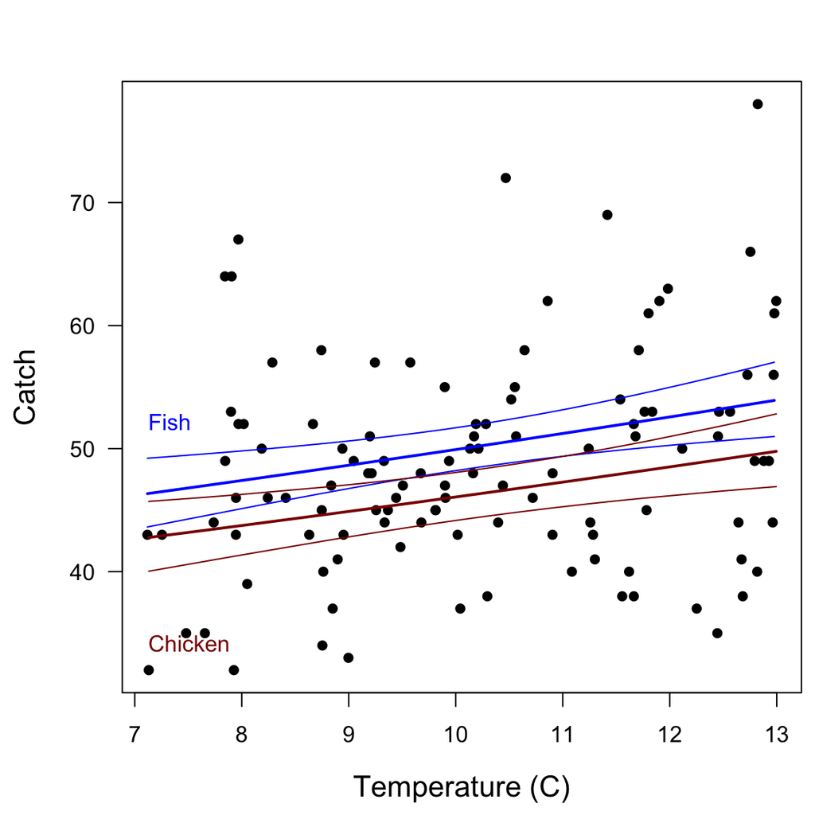

```r
## set plot area
par(mai = c(0.9, 0.9, 0.6, 0.1),
    omi = c(0, 0, 0, 0),
    cex.lab = 1.3)

## temp vs catch
plot(temp, catch, pch = 16, las = 1,
     ylab = "Catch", xlab ="Temperature (C)")
## with fish bait
lines(fdat$temp, fish_fit, lwd = 2, col = "blue")
lines(fdat$temp, fish_lo, lwd = 1, col = "blue")
lines(fdat$temp, fish_hi, lwd = 1, col = "blue")
text(7, 52, "Fish", pos = 4, col = "blue")
## with chicken bait
lines(cdat$temp, chkn_fit, lwd = 2, col = "darkred")
lines(cdat$temp, chkn_lo, lwd = 1, col = "darkred")
lines(cdat$temp, chkn_hi, lwd = 1, col = "darkred")
text(7, 34, "Chicken", pos = 4, col = "darkred")
```

## Model diagnostics

As with other models, it’s important to examine diagnostic checks for our fitted models. The first thing we can do is examine a plot of the model residuals.

### Residuals

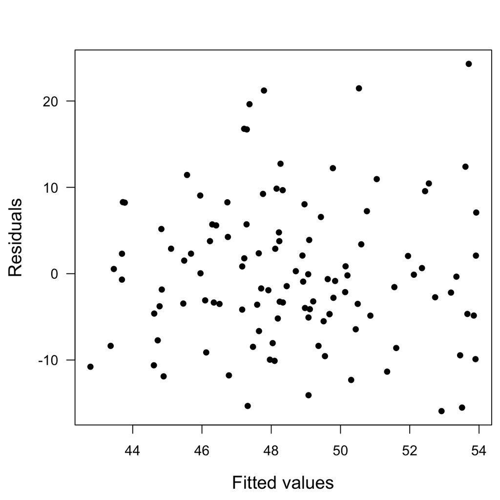

```r
## set plot area
par(mai = c(0.9, 0.9, 0.6, 0.1),
    omi = c(0, 0, 0, 0),
    cex.lab = 1.3)

## resids vs fitted
ee <- prawns$catch - fitted(cmod)
plot(fitted(cmod), ee, pch = 16, las = 1,
     ylab = "Residuals", xlab ="Fitted values")
```

These residuals look good in that there is no obvious pattern (linear, nonlinear), nor is there any evidence of heteroscedasticity.

### Leverage

We can calculate the leverages $h$ to look for unusual observation in *predictor space*. Recall that we are potentially concerned about $h > 2 \frac{k}{n}$. We can use `hatvalues()` to compute the leverages.

```r
## leverages
hat_values <- hatvalues(cmod)
## threshold value
h_crit <- 2 * length(coef(cmod)) / nn
## check if any h_i > b_crit
any(hat_values > h_crit)
```

```
## [1] FALSE
```

None of these points has a leverage greater than our threshold value. We can also use `faraway::halfnorm()` to plot them.

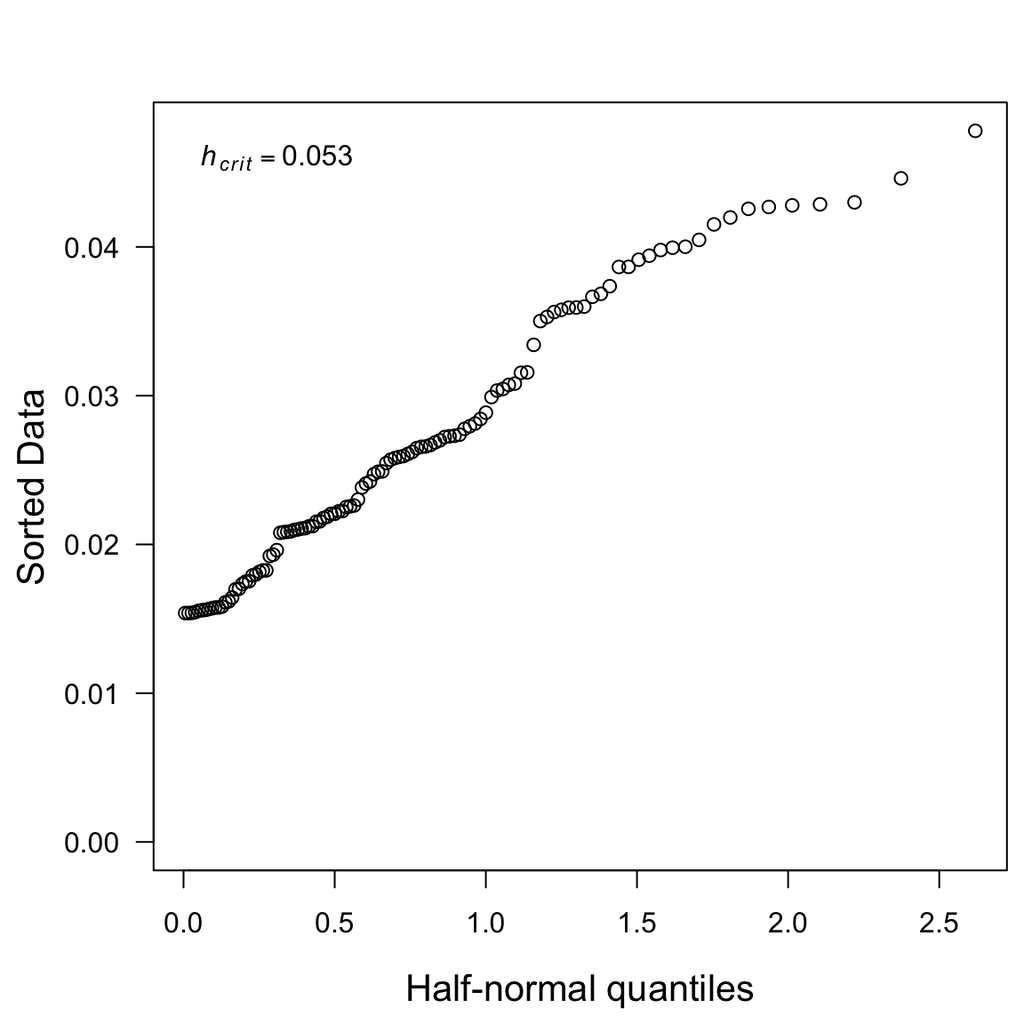

```r
## set plot area
par(mai = c(0.9, 0.9, 0.6, 0.1),
    omi = c(0, 0, 0, 0),
    cex.lab = 1.3)

## halfnormal plot
faraway::halfnorm(hat_values, nlab = 0, labs = "", las = 1)
text(0, 0.92*par("usr")[4],
     substitute(italic(h[crit]) == h_crit, list(h_crit = round(h_crit, 3))),
     pos = 4)
```

### Cook’s Distance

Recall that we can use Cook’s $D$ to identify potentially influential points, where

$$D_{i}=e_{i}^{2} \frac{1}{k}\left(\frac{h_{i}}{1-h_{i}}\right)$$

In general we should be potentially concerned about $D_i > F^{(0.5)}_{n, n - k} \approx 1$.

```r
## Cook's D
CD <- cooks.distance(cmod)
## Threshold value
CD_crit <- qf(0.5, nn, nn - length(coef(cmod)))
## check if any CD_i > CD_crit
any(CD > CD_crit)
```

```
## [1] FALSE
```

It looks like none of the Cook’s $D$ values exceed our threshold value. Let’s plot them with `faraway::halfnorm()`.

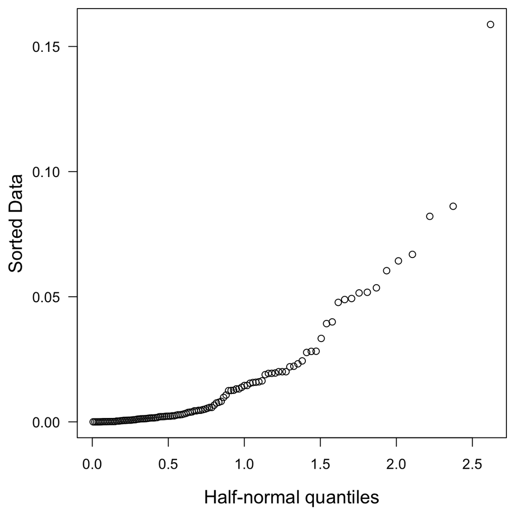

```r
## set plot area
par(mai = c(0.9, 0.9, 0.1, 0.1),
    omi = c(0, 0, 0, 0),
    cex.lab = 1.3)

## halfnormal plot
faraway::halfnorm(CD, nlab = 0, labs = "", las = 1)
```

## Model selection

We can use a likelihood ratio test to compare our model to an intercept-only model

```r
## deviance of full model
D_full <- summary(cmod)$deviance
## deviance of null model
D_null <- summary(cmod)$null.deviance
## test statistic
lambda <- D_null - D_full
## LRT with df = 2
(p_value <- pchisq(lambda, 2, lower.tail = FALSE))
```

```
## [1] 0.0001131307
```

This $p$-value is very small so we reject $H_0$ (that the data come from the null model).

# Overdispersed counts

We saw that logistic regression models based upon the binomial distribution can exhibit overdispersion if the deviance is larger than expected. Poisson regression models are also prone to overdispersion because there is only one parameter specifying both the mean and the variance.

$$y_i \sim \text{Poisson}(\lambda)$$

## Bycatch of green sea turtles

In lecture we used some example data indicative of bycatch of sea turtles in trawl fisheries. Here are the simulated data wherein ~50% of the fleet was outfitted with turtle excluder devices (TEDS) and the number of turtles caught per 1000 trawl hours was recorded along with water temperature.

```r
## number of obs
nn <- 197
## presence/absence of TED
TED <- sample(c(0,1), nn, replace = TRUE)
## temperature
temp <- runif(nn, 15, 25)

## mean bycatch
beta_0 <- -1.5
## effect of TED
beta_1 <- -1.1
## effect of temp
beta_2 <- 0.085

## variance inflation
mu <- 1
vif <- 3

## expectation
mean <- exp(beta_0 + beta_1 * TED + beta_2 * temp)

## bycatch
bycatch <- rnbinom(nn, mu = mean, size = mu^2 / (vif - mu))

## data frame
turtles <- data.frame(bycatch, TED, temp)
```

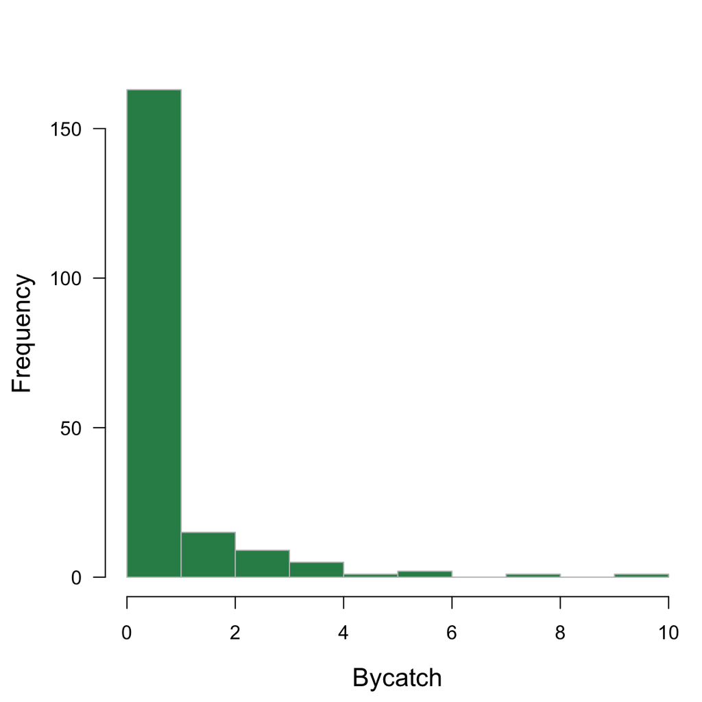

```r
## set plot area
par(mai = c(0.9, 0.9, 0.6, 0.1),
    omi = c(0, 0, 0, 0),
    cex.lab = 1.3)

## histogram of catches
hist(turtles$bycatch, las = 1, breaks = seq(0, max(bycatch)),
     col = "seagreen", border = "gray",
     xlab = "Bycatch", main = "")
```

## Poisson model for bycatch

Let’s begin by fitting a Poisson regression model to bycatch of turtles $y_i$ as a function of TED presence/absence $T_i$ and water temperature $W_i$. Here is the specification of our GLM:

$$\begin{aligned}
\text{data distribution:} & ~~ y_i \sim \text{Poisson}(\lambda_i) \\
\\
\text{link function:} & ~~ \text{log}(\lambda_i) = \eta_i \\ \\
\text{linear predictor:} & ~~ \eta_i = \alpha + \beta_1 T_i +
\beta_2 W_i
\end{aligned}$$

Here is our model fit to the data.

```r
## Poisson regression
ted_mod <- glm(bycatch ~ TED + temp, data = turtles,
               family = poisson(link = "log"))
## model summary
faraway::sumary(ted_mod)
```

```
##              Estimate Std. Error z value  Pr(>|z|)
## (Intercept) -1.449170   0.630344 -2.2990   0.02150
## TED         -0.960144   0.189518 -5.0662 4.057e-07
## temp         0.072820   0.030293  2.4039   0.01622
##
## n = 197 p = 3
## Deviance = 352.47008 Null Deviance = 386.40774 (Difference = 33.93766)
```

## Goodness of fit

As we did above for the prawn model, we can use Pearson’s $\chi^2$ statistic as a goodness-of-fit measure for our turtle model. Here again the null hypothesis is that our model is correctly specified.

```r
## Pearson's X^2 statistic
X2 <- sum((bycatch - fitted(ted_mod))^2 / fitted(ted_mod))
## likelihood ratio test
pchisq(X2, df = nn - length(coef(ted_mod)),
       lower.tail = FALSE)
```

```
## [1] 5.972817e-28
```

The $p$-value is quite small so we reject $H_0$ and conclude that the Poisson model is not a good fit to the data.

### Overdispersion

We can consider the possibility that the variance scales linearly with the mean, such that

$$\text{Var}(y) = c \lambda$$

If $c$ = 1 then $y \sim \text{Poisson}(\lambda)$, and if $c$ > 1 the data are *overdispersed*. We can estimate the overdispersion $\hat{c}$ as

$$\hat{c} = \frac{X^2}{n - k}$$

and

```r
## function to calculate dispersion parameter
c_hat <- function(obs, model) {
  X2 <- sum((obs - fitted(model))^2 / fitted(model))
  return(X2 / (length(obs) - length(coef(model))))
}
## dispersion parameter
(c_hat_ted <- c_hat(bycatch, ted_mod))
```

```
## [1] 2.541267
```

This estimate of dispersion is well above 1 so we should be concerned about its effect on the estimated uncertainty of our model parameters. Therefore, we can tell **R** that we want to account for the overdispersion when estimating the SE for the model parameters by including the `dispersion` argument in `summary()`. Let’s compare the SE’s for both cases.

```r
## regular Poisson
signif(summary(ted_mod)$coefficients, 3)
```

```
##             Estimate Std. Error z value Pr(>|z|)
## (Intercept)  -1.4500     0.6300   -2.30 2.15e-02
## TED          -0.9600     0.1900   -5.07 4.06e-07
## temp          0.0728     0.0303    2.40 1.62e-02
```

```r
## overdispersed Poisson
signif(summary(ted_mod, dispersion = c_hat_ted)$coefficients, 3)
```

```
##             Estimate Std. Error z value Pr(>|z|)
## (Intercept)  -1.4500     1.0000   -1.44  0.14900
## TED          -0.9600     0.3020   -3.18  0.00148
## temp          0.0728     0.0483    1.51  0.13200
```

The SE’s for the overdispersed model are clearly larger. We can see the effect this has on the estimated confidence intervals by overlaying them on plots of the data and zooming in on the lower range of the data.

## Effect of overdispersion

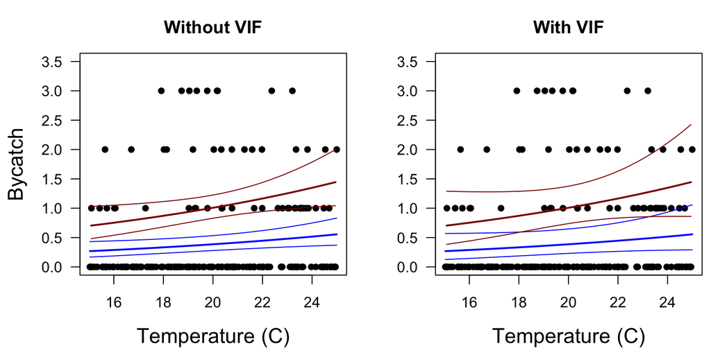

```r
## fitted values
tmp <- turtles[order(turtles[,3]),]
fdat <- tmp[tmp$TED == 1,]
cdat <- tmp[tmp$TED == 0,]
TED <- predict(ted_mod, fdat, se.fit = TRUE, type = "link")
no_TED <- predict(ted_mod, cdat, se.fit = TRUE, type = "link")

## VIF fitted values
tmp2 <- turtles[order(turtles[,3]),]
fdat2 <- tmp2[tmp2$TED == 1,]
cdat2 <- tmp2[tmp2$TED == 0,]
TED2 <- predict(ted_mod, fdat2, se.fit = TRUE, type = "link", dispersion = c_hat_ted)
no_TED2 <- predict(ted_mod, cdat2, se.fit = TRUE, type = "link", dispersion = c_hat_ted)

## t value
t_crit <- qt(0.975, nn - length(coef(ted_mod)))

## set plot area
par(mfrow = c(1,2),
    mai = c(0.9, 0.9, 0.6, 0.1),
    omi = c(0, 0, 0, 0),
    cex.lab = 1.4)

## temp vs bycatch
plot(temp, bycatch, pch = 16, las = 1, ylim = c(0, 3.5),
     ylab = "Bycatch", xlab ="Temperature (C)", main = "Without VIF")
## with TED
lines(fdat$temp, exp(TED$fit), lwd = 2, col = "blue")
lines(fdat$temp, exp(TED$fit + t_crit * TED$se.fit), lwd = 1, col = "blue")
lines(fdat$temp, exp(TED$fit - t_crit * TED$se.fit), lwd = 1, col = "blue")
text(7, 65, "with TED", pos = 4, col = "blue")
## without TED
lines(cdat$temp, exp(no_TED$fit), lwd = 2, col = "darkred")
lines(cdat$temp, exp(no_TED$fit + t_crit * no_TED$se.fit), lwd = 1, col = "darkred")
lines(cdat$temp, exp(no_TED$fit - t_crit * no_TED$se.fit), lwd = 1, col = "darkred")
text(7, 30, "w/o TED", pos = 4, col = "darkred")

## temp vs bycatch
plot(temp, bycatch, pch = 16, las = 1, ylim = c(0, 3.5),
     ylab = "", xlab ="Temperature (C)", main = "With VIF")
## with TED
lines(fdat2$temp, exp(TED2$fit), lwd = 2, col = "blue")
lines(fdat2$temp, exp(TED2$fit + t_crit * TED2$se.fit), lwd = 1, col = "blue")
lines(fdat2$temp, exp(TED2$fit - t_crit * TED2$se.fit), lwd = 1, col = "blue")
text(7, 65, "with TED", pos = 4, col = "blue")
## without TED
lines(cdat$temp, exp(no_TED2$fit), lwd = 2, col = "darkred")
lines(cdat$temp, exp(no_TED2$fit + t_crit * no_TED2$se.fit), lwd = 1, col = "darkred")
lines(cdat$temp, exp(no_TED2$fit - t_crit * no_TED2$se.fit), lwd = 1, col = "darkred")
text(7, 30, "w/o TED", pos = 4, col = "darkred")
```

## Quasi-Poisson models

We saw with the case of overdispersed binomial models that we could use a *quasi-likelihood* to estimate the parameters. To fit these models, we use `family = quasipoisson(link = "log")` in our call to `glm()`. Here are the quasi-likelihood fits compared to the overdispersed Poisson.

```r
## Poisson regression
ted_mod_q <- glm(bycatch ~ TED + temp, data = turtles,
                 family = quasipoisson(link = "log"))
## quasi-Poisson
signif(summary(ted_mod_q)$coefficients, 3)
```

```
##             Estimate Std. Error t value Pr(>|t|)
## (Intercept)  -1.4500     1.0000   -1.44  0.15100
## TED          -0.9600     0.3020   -3.18  0.00173
## temp          0.0728     0.0483    1.51  0.13300
```

```r
## overdispersed Poisson
signif(summary(ted_mod, dispersion = c_hat_ted)$coefficients, 3)
```

```
##             Estimate Std. Error z value Pr(>|z|)
## (Intercept)  -1.4500     1.0000   -1.44  0.14900
## TED          -0.9600     0.3020   -3.18  0.00148
## temp          0.0728     0.0483    1.51  0.13200
```

These estimates indeed very close to one another.

### Quasi-AIC

Just as we did for binomial models, we can use a *quasi*-AIC to compare models, where

$$QAIC = 2 k - 2 \frac{\log \mathcal{L}}{\hat{c}}$$

Here’s a comparison of several possible models for turtle bycatch.

```r
## fit reduced models
ted_ted <- glm(bycatch ~ TED, data = turtles,
               family = poisson(link = "log"))
ted_temp <- glm(bycatch ~ temp, data = turtles,
                family = poisson(link = "log"))
## fit null model
ted_null <- glm(bycatch ~ 1, data = turtles,
                family = poisson(link = "log"))
## get c_hat's
c_hats <- c(c_hat(bycatch, ted_mod),
            c_hat(bycatch, ted_ted),
            c_hat(bycatch, ted_temp),
            c_hat(bycatch, ted_null))

## model selection results
## neg log-likelihoods
tbl_mods <- -c(logLik(ted_mod), logLik(ted_ted),
               logLik(ted_temp), logLik(ted_null))
## k & AIC
tbl_mods <- cbind(tbl_mods, AIC(ted_mod, ted_ted, ted_temp, ted_null))
## delta-AIC
tbl_mods <- cbind(tbl_mods, tbl_mods[,3] - min(tbl_mods[,3]))
## QAIC
tbl_mods <- cbind(tbl_mods, 2 * tbl_mods[,1] + 2 * tbl_mods[,2] / c_hats)
## delta-QAIC
tbl_mods <- cbind(tbl_mods, tbl_mods[,5] - min(tbl_mods[,5]))
## label table
rownames(tbl_mods) <- c("B0 + TED + temp  ", "B0 + TED  ",
                        "B0 + temp  ", "B0 only  ")
colnames(tbl_mods) <- c("neg-LL", "k", "AIC", "deltaAIC", "QAIC", "deltaQAIC")
round(tbl_mods, 1)
```

```
##                   neg-LL k   AIC deltaAIC  QAIC deltaQAIC
## B0 + TED + temp    257.9 3 521.8      0.0 518.2       0.0
## B0 + TED           260.8 2 525.7      3.9 523.3       5.1
## B0 + temp          272.4 2 548.8     26.9 546.2      28.0
## B0 only            274.9 1 551.8     29.9 550.5      32.3
```

## Negative binomial distribution

We have seen several examples in lecture where we can use the negative binomial distribution to model overdispersed data because it has an additional parameter for the spread. Here is the description of a GLM for bycatch of turtles $y_i$ as a function of TED presence/absence $T_i$ and water temperature $W_i$

$$\begin{aligned}
\text{data distribution:} & ~~ y_i \sim \text{negBin}(r, \mu_i) \\
\\
\text{link function:} & ~~ \text{log}(\mu_i) = \eta_i \\ \\
\text{linear predictor:} & ~~ \eta_i = \alpha + \beta_1 T_i +
\beta_2 W_i
\end{aligned}$$

We can model our bycatch data with a negative binomial using `glm.nb()` from the **MASS** package.

```r
## load MASS
library(MASS)
## negative binomial regression
ted_mod_nb <- glm.nb(bycatch ~ TED + temp, data = turtles,
                     link = "log")
```

Let’s compare these estimates to those for the overdispersed and quasi-likelihood models.

```r
## overdispersed Poisson
signif(summary(ted_mod, dispersion = c_hat_ted)$coefficients, 3)
```

```
##             Estimate Std. Error z value Pr(>|z|)
## (Intercept)  -1.4500     1.0000   -1.44  0.14900
## TED          -0.9600     0.3020   -3.18  0.00148
## temp          0.0728     0.0483    1.51  0.13200
```

```r
## quasi-Poisson
signif(summary(ted_mod_q)$coefficients, 3)
```

```
##             Estimate Std. Error t value Pr(>|t|)
## (Intercept)  -1.4500     1.0000   -1.44  0.15100
## TED          -0.9600     0.3020   -3.18  0.00173
## temp          0.0728     0.0483    1.51  0.13300
```

```r
## negative binomial
signif(summary(ted_mod_nb)$coefficients, 3)
```

```
##             Estimate Std. Error z value Pr(>|z|)
## (Intercept)  -1.2900     0.9970   -1.29  0.19600
## TED          -0.9330     0.2840   -3.28  0.00103
## temp          0.0645     0.0486    1.33  0.18400
```

The model estimates from the negative binomial model are rather similar to those from the other methods.

# Zero-truncated counts

Although somewhat rare in ecological studies, we saw some examples in lecture of so-called “zero-truncated data” (e.g., the time a whale is at the surface before diving, herd size in elk, number of fin rays on a fish). We also saw that the data themselves are not a problem, but rather an underlying assumption of a Poisson or negative binomial distribution may be the problem.

## Poisson for zero-truncated data

The probability that $y_i = 0$ is

$$f(y_i; \lambda_i) = \frac{\exp (\text{-} \lambda_i)
\lambda_{i}^{y_i}}{y_i!} \\
\Downarrow \\
\begin{align}
f(y_i = 0; \lambda_i) &= \frac{\exp (\text{-} \lambda_i)
\lambda_{i}^0}{0!} \\
&= \exp (\text{-} \lambda_i)
\end{align}$$

and therefore the probability that $y_i \neq 0$ is

$$f(y_i \neq 0; \lambda_i) = 1 - \exp (\text{-} \lambda_i)$$

We can now exclude the probability that $y_i = 0$ by dividing the pmf by the probability that $y_i \neq 0$

$$f(y_i; \lambda_i) = \frac{\exp (\text{-} \lambda_i)
\lambda_{i}^{y_i}}{y_i!} \\
\Downarrow \\
f^+(y_i; \lambda_i | y_i > 0) = \frac{\exp (\text{-} \lambda_i)
\lambda_{i}^{y_i}}{y_i!} \cdot \frac{1}{1 - \exp (\text{-} \lambda_i)}
\\
\Downarrow \\
\log \mathcal{L} = \left( y_i \log \lambda_i - \lambda_i \right) -
\left( 1 - \exp (\text{-} \lambda_i) \right)$$

## Road-killed snakes

Let’s revisit the data presented in Zuur et al. (2009) on the number of days that carcasses from road-killed snakes stay on roads. The predictors are the total rainfall (mm) and an indicator of whether the snake was killed in the driving lane or the shoulder (or “verve” as it is sometimes called). Let’s begin by loading and plotting the data.

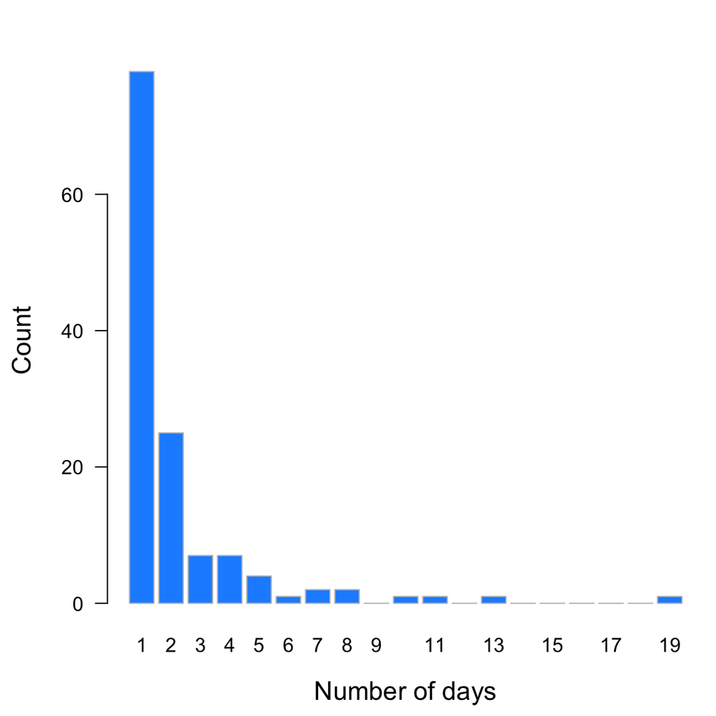

```r
## read data
snakes <- read.csv("snakes.csv", stringsAsFactors = FALSE)

## set plot area
par(mai = c(0.9, 0.9, 0.6, 0.1),
    omi = c(0, 0, 0, 0), bg = NA,
    cex.lab = 1.3)
## histogram
hh <- hist(snakes$n_days, breaks = seq(0, max(snakes$n_days)), plot = FALSE)
barplot(hh$counts, names.arg = seq(max(snakes$n_days)), las = 1,
        ylab = "Count", xlab = "Number of days",
        col = "dodgerblue", border = "gray")
```

## Poisson model

Let’s first consider a regular Poisson regression model, which has a non-zero likelihood of producing zeros.

```r
## Poisson regression
smod_pois <- glm(n_days ~ location + rain, data = snakes,
                 family = poisson(link = "log"))
## model summary
summary(smod_pois)
```

```
##
## Call:
## glm(formula = n_days ~ location + rain, family = poisson(link = "log"),
##     data = snakes)
##
## Coefficients:
##             Estimate Std. Error z value Pr(>|z|)
## (Intercept) 0.439195   0.088539   4.960 7.03e-07 ***
## locationV   0.462663   0.119060   3.886 0.000102 ***
## rain        0.021707   0.003092   7.021 2.21e-12 ***
## ---
## Signif. codes:  0 '***' 0.001 '**' 0.01 '*' 0.05 '.' 0.1 ' ' 1
##
## (Dispersion parameter for poisson family taken to be 1)
##
##     Null deviance: 226.38  on 129  degrees of freedom
## Residual deviance: 175.80  on 127  degrees of freedom
## AIC: 497.63
##
## Number of Fisher Scoring iterations: 5
```

## Zero-truncated Poisson

Now let’s fit a zero-truncated Poisson regression model with `vglm()` from **VGAM** and compare the results to our regular Poisson model above. To do so, we need to specify `family = pospoisson` to indicate we want a zero-truncated Poisson distribution.

```r
library(VGAM)
## zero-truncated Poisson regression
smod_ztpois <- vglm(n_days ~ location + rain, data = snakes,
                    family = pospoisson)

## parameter MLEs and SEs for Poisson
beta_hat_p <- cbind(coef(smod_pois), sqrt(diag(vcov(smod_pois))))
## parameter MLEs and SEs for Poisson+
beta_hat_ztp <- cbind(coef(smod_ztpois), sqrt(diag(vcov(smod_ztpois))))

## table of results
tbl_pois <- round(cbind(beta_hat_p, beta_hat_ztp), 3)
colnames(tbl_pois) <- c("  Poisson", "  Poisson SE", "  +Poisson", "  +Poisson SE")
tbl_pois
```

```
##               Poisson   Poisson SE   +Poisson   +Poisson SE
## (Intercept)     0.439        0.089      0.041         0.125
## locationV       0.463        0.119      0.711         0.149
## rain            0.022        0.003      0.027         0.003
```

Here we can see that MLE’s from the regular Poisson model are biased high and low for the intercept and location effect, respectively. The SE’s for the Poisson model are also biased low.

## Zero-truncated negative binomial

Recall that for $y_i \sim \text{negBinom}(r, \mu)$, its probability mass function is

$$f(y; \mu, r) = \frac{(y+r-1) !}{(r-1) ! y !} \left( \frac{r}{\mu + r}
\right)^{r}\left( \frac{\mu}{\mu + r} \right)^{y}$$

The probability that $y_i = 0$ is

$$f(y; r, \mu) = \frac{(y+r-1) !}{(r-1) ! y !} \left( \frac{r}{\mu + r}
\right)^{r}\left( \frac{\mu}{\mu + r} \right)^{y} \\
\Downarrow \\
\begin{align}
f(y_i = 0; r, \mu) &= \frac{(0+r-1) !}{(r-1) ! 0 !} \left(
\frac{r}{\mu + r} \right)^{r} \left( \frac{\mu}{\mu + r} \right)^{0} \\
&= \left( \frac{r}{\mu + r} \right)^{r}
\end{align}$$

and the probability that $y_i \neq 0$ is therefore

$$f(y_i \neq 0; r, \mu_i) = 1 - \left( \frac{r}{\mu + r} \right)^{r}$$

Just as we did for the Poisson distribution, we can now exclude the probability that $y_i = 0$ by dividing the pmf by the probability that $y_i \neq 0$

$$f(y; r, \mu) = \frac{(y+r-1) !}{(r-1) ! y !} \left( \frac{r}{\mu + r}
\right)^{r} \left( \frac{\mu}{\mu + r} \right)^{y} \\
\Downarrow \\
f^+(y_i; \lambda_i | y_i > 0) = \frac{ \frac{(y+r-1) !}{(r-1) ! y !}
\left( \frac{r}{\mu + r} \right)^{r} \left( \frac{\mu}{\mu + r}
\right)^{y} }{ 1 - \left( \frac{r}{\mu + r} \right)^{r} } \\
\Downarrow \\
\log \mathcal{L} = \log \mathcal{L}(\text{NB}) - \log \left( 1 - \left(
\frac{r}{\mu + r} \right)^{r} \right)$$

## Road-killed snakes

Let’s first consider a regular negative binomial regression model to which we can compare a zero-truncated version.

```r
## load MASS pkg
library(MASS)
## negative binomial regression
smod_nb <- glm.nb(n_days ~ location + rain, data = snakes,
                  link = "log")
## model summary
summary(smod_nb)
```

```
##
## Call:
## glm.nb(formula = n_days ~ location + rain, data = snakes, link = "log",
##     init.theta = 4.153875871)
##
## Coefficients:
##             Estimate Std. Error z value Pr(>|z|)
## (Intercept) 0.418101   0.106859   3.913 9.13e-05 ***
## locationV   0.453524   0.151708   2.989  0.00279 **
## rain        0.025127   0.004529   5.548 2.88e-08 ***
## ---
## Signif. codes:  0 '***' 0.001 '**' 0.01 '*' 0.05 '.' 0.1 ' ' 1
##
## (Dispersion parameter for Negative Binomial(4.1539) family taken to be 1)
##
##     Null deviance: 128.298  on 129  degrees of freedom
## Residual deviance:  94.918  on 127  degrees of freedom
## AIC: 469.28
##
## Number of Fisher Scoring iterations: 1
##
##
##               Theta:  4.15
##           Std. Err.:  1.17
##
##  2 x log-likelihood:  -461.279
```

Right away we can see that the deviance for this model is much more in line with our expectation. Now let’s fit a zero-truncated negative binomial regression model with `vglm()` from **VGAM** and compare it to the regular negative binomial model. Here we need to specify `family = posnegbinomial` to specify a zero-truncated negative binomial.

```r
library(VGAM)
## zero-truncated negative binomial regression
smod_ztnb <- vglm(n_days ~ location + rain, data = snakes,
                  family = posnegbinomial)

## MLEs and SEs for regular NB
beta_hat_nb <- cbind(coef(smod_nb), sqrt(diag(vcov(smod_nb))))
## MLEs and SEs for regular NB+
beta_hat_ztnb <- cbind(coef(smod_ztnb)[-2], sqrt(diag(vcov(smod_ztnb))[-2]))

## table of results
tbl_nb <- round(cbind(beta_hat_nb, beta_hat_ztnb), 3)
colnames(tbl_nb) <- c("  NB", "  NB SE", "      +NB", " +NB SE")
tbl_nb
```

```
##                NB   NB SE       +NB  +NB SE
## (Intercept) 0.418   0.107   -17.972   1.948
## locationV   0.454   0.152     0.965   2.933
## rain        0.025   0.005     0.065   0.103
```

This is a particularly impressive example of the biases in MLE’s and the associated SE’s that one would get by fitting the wrong model.

# Zero-inflated counts

Count data that have an excess of zeros tend to be more common in ecological studies. These *zero-inflated* data contain more zeros than would be expected under a Poisson or negative binomial distribution. In general, there are 4 different types of errors that cause zeros

1. Structural (an animal is absent because the habitat is unsuitable)
2. Design (sampling is limited temporally or spatially)
3. Observer error (inexperience or difficult circumstances)
4. Process error (habitat is suitable but unused)

## Approaches to zero-inflated data

There are 2 general approaches for dealing with zero-inflated data, which differ in their assumption about the underlying sources of the excess zeros:

1. Zero-altered (“hurdle”) models
2. Zero-inflated (“mixture”) models

Zero-altered (ZA) models do not discriminate among the 4 types of zeros and treat all of the count data as belonging to one of two distinct groups: zeros and non-zeros. Zero-inflated (ZI) models also treat the zeros as coming from two sources, but they arise either via observation errors (missed detections) or ecological reasons (the plant or animal was absent because of the environment). The primary difference is that ZA models treat the non-zeros as zero-truncated data whereas ZI models treat the non-zeros and *some of the zeros* as coming from a regular Poisson or negative binomial distribution. Here is a graphical depiction of the two cases.

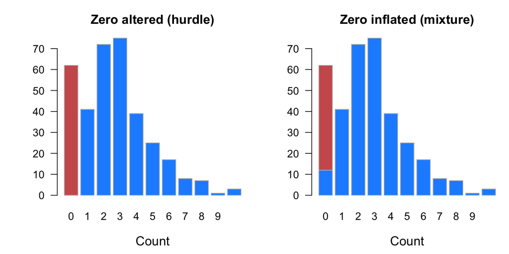

```r
## extra zeros + Poisson(3)
set.seed(514)
all <- c(rep(0, 50), rpois(300, 3))
## ZAP
idx_zap <- ifelse(all > 0, 0, 1)
all_zap <- table(all, idx_zap)
## ZIP
idx_zip <- c(rep(1, 50), rep(0, 300))
all_zip <- table(all, idx_zip)

## set plot area
par(mfrow = c(1, 2),
    mai = c(0.9, 0.9, 0.6, 0.1),
    omi = c(0, 0, 0, 0), bg = NA,
    cex.main = 1.2, cex.lab = 1.2)

## bar charts of the data
barplot(t(all_zap), las = 1, col=c("dodgerblue","indianred"), border ="gray",
        xlab = "Count", main = "Zero altered (hurdle)")
barplot(t(all_zip), las = 1, col=c("dodgerblue","indianred"), border ="gray",
        xlab = "Count", main = "Zero inflated (mixture)")
```

## Zero-altered Poisson

Zero-altered models consist of 2 parts:

1. a binomial model to determine the probability of a zero
2. a truncated Poisson or negative binomial to model the positive counts

Here we’ll consider a zero-altered Poisson (ZAP) model, which is given by

$$f_{\text{ZAP}}(y; \pi, \lambda) =
\left\{
\begin{array}{lc}
f_{\text{binomial}}(y = 0; \pi) \\
\left[1 - f_{\text{binomial}}(y = 0; \pi) \right] \times \left(
\frac{f_{\text{Poisson}}(y = 0; \lambda)}{1 - f_{\text{Poisson}}(y = 0;
\lambda)} \right)
\end{array}
\right.$$

where $\pi$ is the probability of finding *any* individuals, and $\lambda$ is the mean (and variance) of the *positive counts*.

We can model both parameters as functions of covariates, such that the logit-transformed probability of detection is given by

$$\text{logit}(\pi) = \mathbf{X}_d \boldsymbol{\beta}_d$$

and the log-transformed mean and variance of the positive counts is given by

$$\log(\lambda) = \mathbf{X}_c \boldsymbol{\beta}_c$$

## Counts of hippos

Let’s apply a ZAP model to our fictitious survey data for hippos, where we assume the following the probability of finding hippos increases with water availability and the number of hippos increases with tree density. We’ll model detection as a function of water availability $W$, such that

$$z_i \sim \text{Bernoulli}(\pi_i) \\
\text{logit}(\pi) = \gamma_0 + \gamma_1 W_i$$

and the positive counts as a function of tree density $T$, such that

$$c_i \sim \text{Poisson}^+(\lambda_i) \\
\log(\lambda) = \beta_0 + \beta_1 T_i$$

Total counts are then a function of the non-zero detections and the positive counts

$$y_i = z_i c_i$$

Here’s how we simulate the zero-inflated data.

```r
## function to generate positive Poisson values
rtpois <- function(n, l) {
  qpois(runif(n, dpois(0, l), 1), l)
}

set.seed(514)
## sample size
nn <- 200
## parameters for detection model
gamma_0 <- -2
gamma_tree <- 3
## parameters for count model
beta_0 <- 2
beta_tree <- 0.8
## covariates
water <- runif(nn, 0, 1)
trees <- runif(nn, 0, 1)
## expectation for Pr(detect)
mu <- 1/(1+exp(-(gamma_0 + gamma_tree * water)))
## detections (0/1)
z <- rbinom(nn, 1, mu)
## expectation for pos counts
lambda <- exp(beta_0 + beta_tree * trees)
## pos counts
pos_count <- rtpois(nn, lambda)
## observations
y <- z * pos_count
```

Here is a plot of the simulated hippo counts.

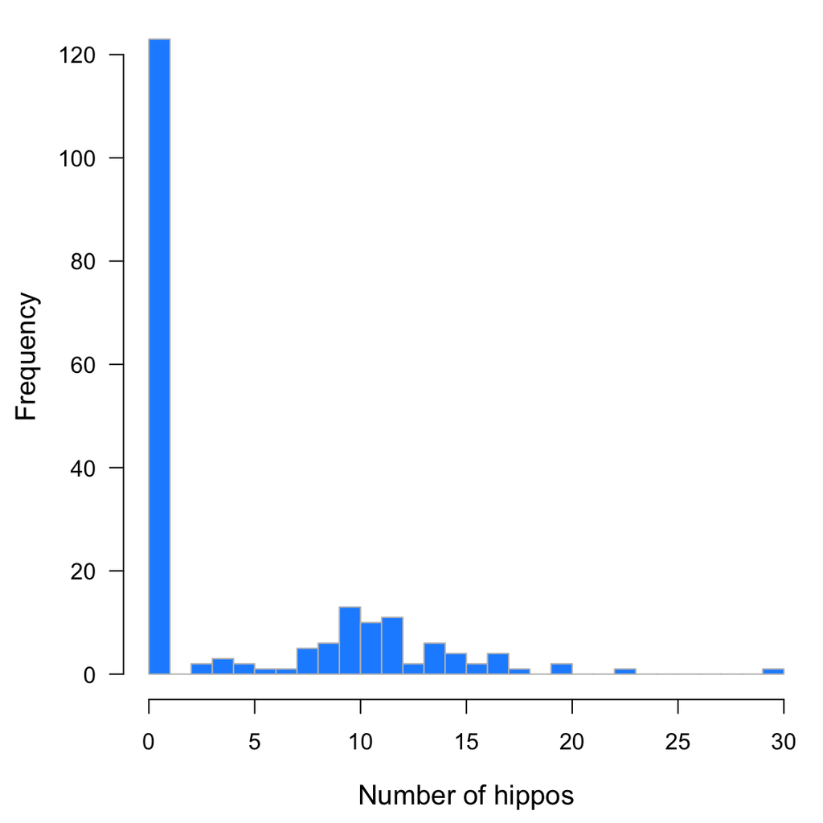

```r
## set plot area
par(mai = c(0.9, 0.9, 0.1, 0.1),
    omi = c(0, 0, 0, 0), bg = NA,
    cex.main = 1.2, cex.lab = 1.2)

## histogram of counts
hist(y, breaks = seq(0, max(y)), las = 1, col = "dodgerblue", border = "gray",
     main = "", xlab = "Number of hippos", ylab = "Frequency", )
```

## ZAP model for hippos

We can fit ZAP models in R with `hurdle()` from the **pscl** package. Note that the formula for ZAP models is specified as `y ~ predictors_of_counts | predictors_for_detection`.

```r
## load pscl
library(pscl)
## fit hurdle model
hippo_zap <- hurdle(y ~ trees | water)
## model summary
summary(hippo_zap)
```

```
##
## Call:
## hurdle(formula = y ~ trees | water)
##
## Pearson residuals:
##     Min      1Q  Median      3Q     Max
## -1.2165 -0.7104 -0.4803  0.9193  2.6988
##
## Count model coefficients (truncated poisson with log link):
##             Estimate Std. Error z value Pr(>|z|)
## (Intercept)  2.05104    0.06955  29.492  < 2e-16 ***
## trees        0.74967    0.10843   6.914 4.71e-12 ***
## Zero hurdle model coefficients (binomial with logit link):
##             Estimate Std. Error z value Pr(>|z|)
## (Intercept)  -1.7326     0.3519  -4.924 8.48e-07 ***
## water         2.3422     0.5676   4.126 3.69e-05 ***
## ---
## Signif. codes:  0 '***' 0.001 '**' 0.01 '*' 0.05 '.' 0.1 ' ' 1
##
## Number of iterations in BFGS optimization: 11
## Log-likelihood: -326.1 on 4 Df
```

The model summary gives us the parameter estimates for both the detection model and the count model. The parameter estimates are pretty close to the true values above, but the slope for the effect of water availability is a bit low.

We can plot the relationships between water availability and the probability of detection, and the estimated count as a function of our index of tree density.

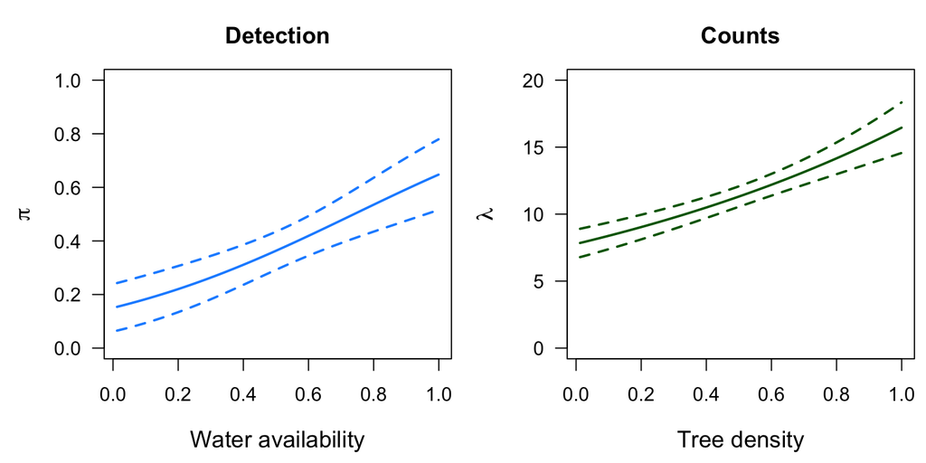

```r
## fitted for detection prob (pi)
water <- sort(water)
gamma_hat_0 <- coef(hippo_zap)[3]
gamma_hat_1 <- coef(hippo_zap)[4]
pi_hat <- 1/(1+exp(-(gamma_hat_0 + gamma_hat_1*water)))

## matrix of derivatives for SE's
derivs <- matrix(NA,nrow=nn,ncol=4)
derivs[,1] <- derivs[,2] <- 0
derivs[,3] <- (exp(gamma_hat_0 + gamma_hat_1*water)) / ((exp(gamma_hat_0 + gamma_hat_1*water)+1)^2)
derivs[,4] <- (water * exp(gamma_hat_0 + gamma_hat_1*water)) / ((exp(gamma_hat_0 + gamma_hat_1*water)+1)^2)
se <- sqrt( diag ( derivs %*% vcov(hippo_zap) %*% t(derivs) ))
lower <- pi_hat - se * qt(0.025, nn-2, lower.tail = FALSE)
upper <- pi_hat + se * qt(0.025, nn-2, lower.tail = FALSE)

## fitted for mean & var (lambda)
trees <- sort(trees)
beta_hat_0 <- coef(hippo_zap)[1]
beta_hat_1 <- coef(hippo_zap)[2]
lambda_hat <- exp(beta_hat_0 + beta_hat_1*trees)

## matrix of derivatives for SE's
derivs_2 <- matrix(NA,nrow=nn,ncol=4)
derivs_2[,1] <- exp(beta_hat_0+beta_hat_1*trees)
derivs_2[,2] <- trees*exp(beta_hat_0+beta_hat_1*trees)
derivs_2[,3] <- derivs_2[,4] <- 0
se_2 <- sqrt( diag ( derivs_2 %*% vcov(hippo_zap) %*% t(derivs_2) ))
lower_2 <- lambda_hat - se_2 * qt(0.025, nn-2, lower.tail = FALSE)
upper_2 <- lambda_hat + se_2 * qt(0.025, nn-2, lower.tail = FALSE)

## set plot area
par(mfrow = c(1, 2),
    mai = c(0.9, 0.9, 0.6, 0.1),
    omi = c(0, 0, 0, 0), bg = NA,
    cex.main = 1.2, cex.lab = 1.2)
## detections
plot(water, pi_hat, type = "l", las = 1, ylim = c(0, 1), lwd = 2, col = "dodgerblue",
     xlab = "Water availability", ylab = expression(pi), main = "Detection")
lines(water, lower, lty = 2,  col = "dodgerblue", lwd = 2)
lines(water, upper, lty = 2,  col = "dodgerblue", lwd = 2)
## counts
plot(trees, lambda_hat, type = "l", las = 1, ylim = c(0, 20), lwd = 2, col = "darkgreen",
     xlab = "Tree density", ylab = expression(lambda), main = "Counts")
lines(trees, lower_2, lty = 2, col = "darkgreen", lwd = 2)
lines(trees, upper_2, lty = 2, col = "darkgreen", lwd = 2)
```

## Zero-inflated Poisson

Zero-inflated Poisson (ZIP) models consist of 2 parts

1. a binomial model to determine the probability of a zero
2. a Poisson model for counts, which can include zeros

Recall that the probability of a zero count comes from 2 sources:

1. false zeros (missed detections)
2. true zeros (ecological reasons)

which means

Pr(zero) = Pr(false zero) + Pr(true zero) $\times$ Pr(count = 0)

Thus, a zero-inflated Poisson (ZIP) model is given by

$$\begin{align}
f_{\text{ZIP}}(y = 0) &= f_{\text{Binomial}}(\pi) + [1 -
f_{\text{Binomial}}(\pi)] f_{\text{Poisson}}(y = 0; \lambda) \\
~ \\
f_{\text{ZIP}}(y | y > 0) &= [1 - f_{\text{Binomial}}(\pi)]
f_{\text{Poisson}}(y; \lambda) \\
\end{align}$$

where $\pi$ is the probability of *false zeros* (missed detections) and $\lambda$ is the mean (and variance) of *all counts* (including zeros)

## Counts of deer

Let’s apply a ZIP model to a simulated survey for white tailed deer where we’ll assume that the probability of *not* detecting deer increases with tree density $T$, such that

$$z_i \sim \text{Bernoulli}(\pi_i) \\
\text{logit}(\pi) = \gamma_0 + \gamma_1 T_i$$

and the counts of deer also increase with tree density $T$, such that

$$c_i \sim \text{Poisson}(\lambda_i) \\
\log(\lambda) = \beta_0 + \beta_1 T_i$$

Total counts as a function of non-detections and positive counts

$$y_i = (1 - z_i) c_i$$

Here are the simulated data.

```r
set.seed(514)
## sample size
nn <- 200
## parameters for detection model
gamma_0 <- 0.01
gamma_tree <- 3
## parameters for count model
beta_0 <- 1.5
beta_tree <- 1.2
## covariate
trees <- runif(nn, 0, 1)
## expectation for Pr(detect)
mu <- 1 / (1 + exp(-(gamma_0 + gamma_tree * trees)))
## missed detections (0/1)
z <- rbinom(nn, 1, mu)
## expectation for pos counts
lambda <- exp(beta_0 + beta_tree * trees)
## pos counts
pos_count <- rpois(nn, lambda)
## observations
y <- (1 - z) * pos_count
```

Here is a histogram of the deer counts

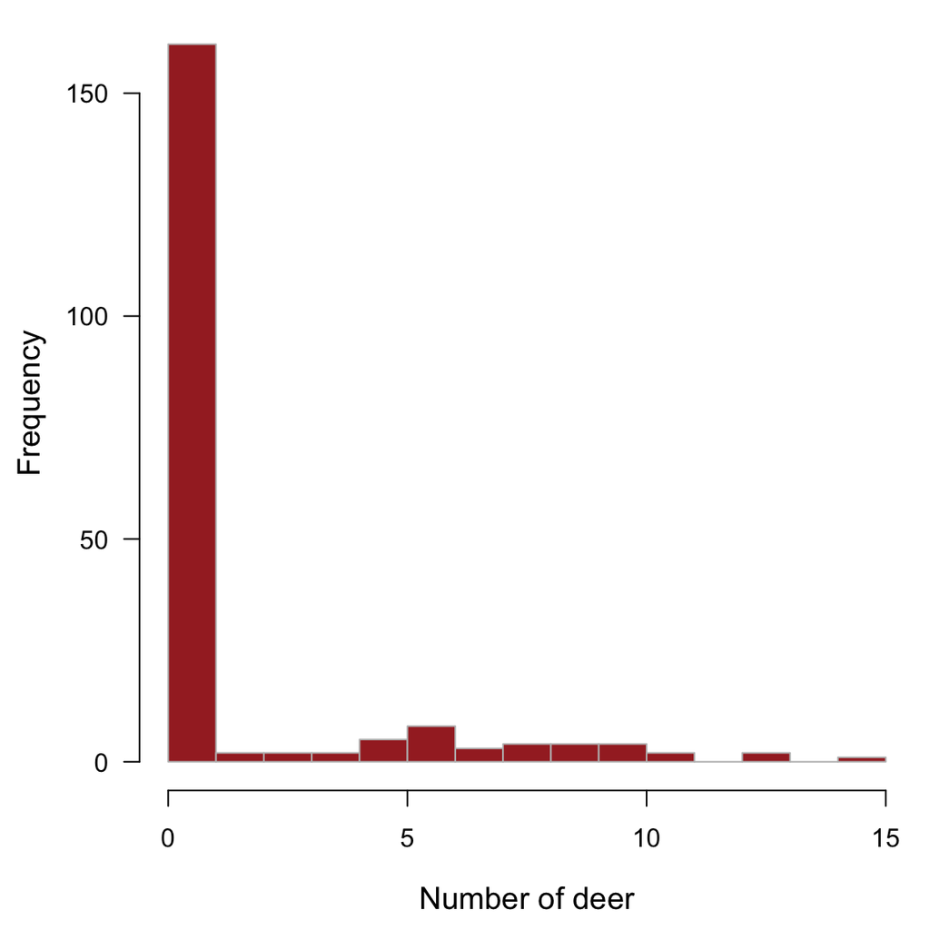

```r
## set plot area
par(mai = c(0.9, 0.9, 0.1, 0.1),
    omi = c(0, 0, 0, 0), bg = NA,
    cex.main = 1.2, cex.lab = 1.2)

## histogram of counts
hist(y, breaks = seq(0, max(y)), las = 1, col = "brown", border = "gray",
     main = "", xlab = "Number of deer", ylab = "Frequency", )
```

## ZIP model for deer

We can fit ZIP models in R with `zeroinfl()` from the **pscl** package, where again we specify the formula as `y ~ predictors_of_counts | predictors_for_detection`.

```r
## fit hurdle model
deer_zip <- zeroinfl(y ~ trees | trees)
## model summary
summary(deer_zip)
```

```
##
## Call:
## zeroinfl(formula = y ~ trees | trees)
##
## Pearson residuals:
##     Min      1Q  Median      3Q     Max
## -0.7312 -0.5103 -0.3674 -0.2611  4.1697
##
## Count model coefficients (poisson with log link):
##             Estimate Std. Error z value Pr(>|z|)
## (Intercept)   1.5190     0.1183  12.841  < 2e-16 ***
## trees         1.0660     0.2272   4.693 2.69e-06 ***
##
## Zero-inflation model coefficients (binomial with logit link):
##             Estimate Std. Error z value Pr(>|z|)
## (Intercept)   0.2625     0.3438   0.764 0.445104
## trees         2.4158     0.7048   3.428 0.000609 ***
## ---
## Signif. codes:  0 '***' 0.001 '**' 0.01 '*' 0.05 '.' 0.1 ' ' 1
##
## Number of iterations in BFGS optimization: 12
## Log-likelihood: -185.8 on 4 Df
```

Here, too, the estimated parameters for both the detection and count models *generally* agree with the true values, although the estimated intercept appears to be non-significant.

As we did for the ZAP model for hippos, we can plot the estimated probability of non-detection and expected count as a function of tree density.

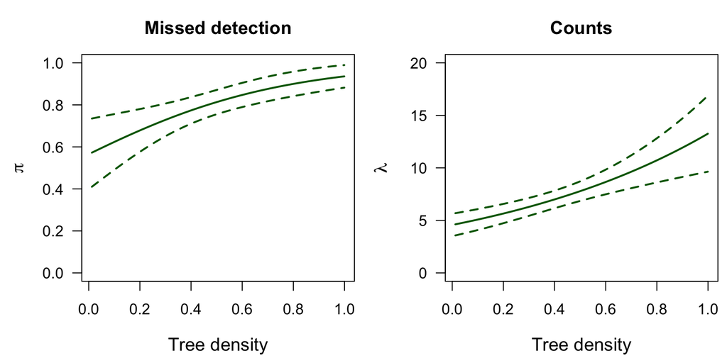

```r
## fitted for detection prob (pi)
trees <- sort(trees)
gamma_hat_0 <- coef(deer_zip)[3]
gamma_hat_1 <- coef(deer_zip)[4]
pi_hat <- 1/(1+exp(-(gamma_hat_0 + gamma_hat_1 * trees)))

## matrix of derivatives
derivs <- matrix(NA, nrow = nn, ncol = 4)
derivs[,1] <- derivs[,2] <- 0
derivs[,3] <- (exp(gamma_hat_0 + gamma_hat_1*trees))/((exp(gamma_hat_0 + gamma_hat_1*trees)+1)^2)
derivs[,4] <- (trees*exp(gamma_hat_0 + gamma_hat_1*trees))/((exp(gamma_hat_0 + gamma_hat_1*trees)+1)^2)
se <- sqrt( diag ( derivs %*% vcov(deer_zip) %*% t(derivs) ))
lower <- pi_hat - se * qt(0.025, nn-2, lower.tail = FALSE)
upper <- pi_hat + se * qt(0.025, nn-2, lower.tail = FALSE)

## fitted for mean & var (lambda)
beta_hat_0 <- coef(deer_zip)[1]
beta_hat_1 <- coef(deer_zip)[2]
lambda_hat <- exp(beta_hat_0 + beta_hat_1*trees)

## matrix of derivatives
derivs_2 <- matrix(NA, nrow = nn, ncol = 4)
derivs_2[,1] <- exp(beta_hat_0+beta_hat_1*trees)
derivs_2[,2] <- trees*exp(beta_hat_0+beta_hat_1*trees)
derivs_2[,3] <- derivs_2[,4] <- 0
se_2 <- sqrt( diag ( derivs_2 %*% vcov(deer_zip) %*% t(derivs_2) ))
lower_2 <- lambda_hat - se_2 * qt(0.025, nn-2, lower.tail = FALSE)
upper_2 <- lambda_hat + se_2 * qt(0.025, nn-2, lower.tail = FALSE)

## set plot area
par(mfrow = c(1, 2),
    mai = c(0.9, 0.9, 0.6, 0.1),
    omi = c(0, 0, 0, 0), bg = NA,
    cex.main = 1.2, cex.lab = 1.2)
## detections
plot(trees, pi_hat, type = "l", las = 1, ylim = c(0, 1), lwd = 2, col = "darkgreen",
     xlab = "Tree density", ylab = expression(pi), main = "Missed detection")
lines(trees, lower, lty = 2,  col = "darkgreen", lwd = 2)
lines(trees, upper, lty = 2,  col = "darkgreen", lwd = 2)
## counts
plot(trees, lambda_hat, type = "l", las = 1, ylim = c(0, 20), lwd = 2, col = "darkgreen",
     xlab = "Tree density", ylab = expression(lambda), main = "Counts")
lines(trees, lower_2, lty = 2, col = "darkgreen", lwd = 2)
lines(trees, upper_2, lty = 2, col = "darkgreen", lwd = 2)
```